# Boston Marathon Analysis

### Question: do we see any significant difference between pace profiles in different years?

```r
boston2015['year'] <- 2015
boston2016['year'] <- 2016
boston2017['year'] <- 2017

df_all <- rbind(boston2015, boston2016) %>% rbind(boston2017)

res.aov <- aov(secondRelFirst ~ factor(year), data = df_all)
kable(tidy(res.aov))
kable(glance(res.aov))

fit1 <- lm(secondRelFirst ~ factor(year), data = df_all)
kable(tidy(fit1), digits = 7)
```

[output not shown]

It looks that there is technically a significant difference in the ratio of second half pace to first half pace between the years, this looks to be largely driven by 2015 having a smaller average ratio than the other two years (1.09 versus 1.15 and 1.15), which might be due to the weather (2015 was cooler than 2016 and 2017, with starting temperature of 41°F versus 67°F for 2016 and 72°F for 2017) [[source](http://findmymarathon.com/weather-detail.php?zname=Boston%20Marathon&year=)].

### Question: Do we see differences in pace profiles by gender?

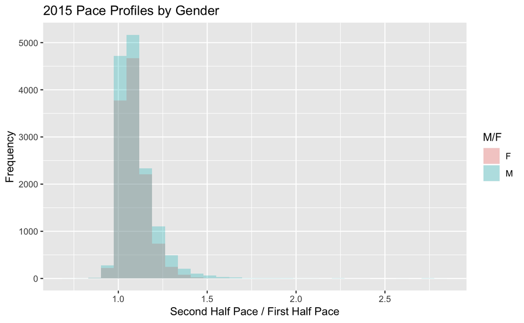

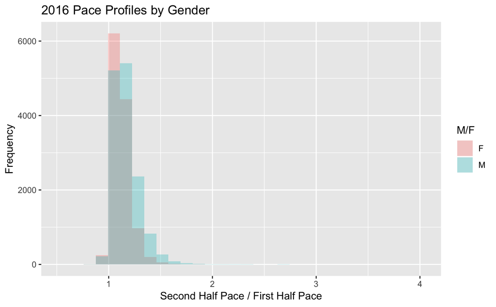